# Employee Attrition Analysis for IBM HR Data

[output not shown]

```r
#load data saved as rds
hrDataRaw <- read_rds("IBM-HR-Data-Full.rds")
hrDataRaw <- as.data.frame(hrDataRaw)
glimpse(hrDataRaw)
```

```
## Observations: 1,470
## Variables: 35
## $ Age                      <dbl> 41, 49, 37, 33, 27, 32, 59, 30, 38, 3...
## $ Attrition                <chr> "Yes", "No", "Yes", "No", "No", "No",...
## $ BusinessTravel           <chr> "Travel_Rarely", "Travel_Frequently",...
## $ DailyRate                <dbl> 1102, 279, 1373, 1392, 591, 1005, 132...
## $ Department               <chr> "Sales", "Research & Development", "R...
## $ DistanceFromHome         <dbl> 1, 8, 2, 3, 2, 2, 3, 24, 23, 27, 16, ...
## $ Education                <dbl> 2, 1, 2, 4, 1, 2, 3, 1, 3, 3, 3, 2, 1...
## $ EducationField           <chr> "Life Sciences", "Life Sciences", "Ot...
## $ EmployeeCount            <dbl> 1, 1, 1, 1, 1, 1, 1, 1, 1, 1, 1, 1, 1...
## $ EmployeeNumber           <dbl> 1, 2, 4, 5, 7, 8, 10, 11, 12, 13, 14,...
## $ EnvironmentSatisfaction  <dbl> 2, 3, 4, 4, 1, 4, 3, 4, 4, 3, 1, 4, 1...
## $ Gender                   <chr> "Female", "Male", "Male", "Female", "...
## $ HourlyRate               <dbl> 94, 61, 92, 56, 40, 79, 81, 67, 44, 9...
```

[output cut: 22 more lines]

## Preprocessing Data

```r
#remove variables that are not useful
row.names(hrDataRaw) <- hrDataRaw$EmployeeNumber
hrData <- hrDataRaw%>%select(-StandardHours, -Over18, -EmployeeCount, -EmployeeNumber)

# convert attrition to binary
hrData$AttrBin <- if_else(hrData$Attrition=="Yes",1,0)

# convert overtime to binary
hrData$OverTimeBin <- if_else(hrData$OverTime == "Yes", 1, 0)
```

```r
#check for missing values
sum(!complete.cases(hrData))
```

```
## [1] 0
```

```r
#in detail
sapply(hrData, function(x) sum(is.na(x)))
```

```
##                      Age                Attrition           BusinessTravel
##                        0                        0                        0
##                DailyRate               Department         DistanceFromHome
##                        0                        0                        0
##                Education           EducationField  EnvironmentSatisfaction
##                        0                        0                        0
##                   Gender               HourlyRate           JobInvolvement
##                        0                        0                        0
##                 JobLevel                  JobRole          JobSatisfaction
##                        0                        0                        0
##            MaritalStatus            MonthlyIncome              MonthlyRate
##                        0                        0                        0
##       NumCompaniesWorked                 OverTime        PercentSalaryHike
##                        0                        0                        0
##        PerformanceRating RelationshipSatisfaction         StockOptionLevel
##                        0                        0                        0
##        TotalWorkingYears    TrainingTimesLastYear          WorkLifeBalance
##                        0                        0                        0
##           YearsAtCompany       YearsInCurrentRole  YearsSinceLastPromotion
##                        0                        0                        0
##     YearsWithCurrManager                  AttrBin              OverTimeBin
##                        0                        0                        0
```

There are no missing values, no need to impute/fill in values.

```r
#convert categorical variables to factors
hrData$Attrition<-factor(hrData$Attrition)
hrData$BusinessTravel<-factor(hrData$BusinessTravel)
hrData$Department<-factor(hrData$Department)
hrData$Education <- factor(hrData$Education)
hrData$EducationField<-factor(hrData$EducationField)
hrData$EnvironmentSatisfaction <- factor(hrData$EnvironmentSatisfaction)
hrData$Gender<-factor(hrData$Gender)
hrData$JobRole<-factor(hrData$JobRole)
hrData$JobInvolvement <- factor(hrData$JobInvolvement)
hrData$JobLevel <- factor(hrData$JobLevel)
hrData$JobSatisfaction <- factor(hrData$JobSatisfaction)
hrData$MaritalStatus<-factor(hrData$MaritalStatus)
hrData$OverTime<-factor(hrData$OverTime)
hrData$PerformanceRating <- factor(hrData$PerformanceRating)
hrData$RelationshipSatisfaction <- factor(hrData$RelationshipSatisfaction)
hrData$StockOptionLevel <- factor(hrData$StockOptionLevel)
hrData$WorkLifeBalance <- factor(hrData$WorkLifeBalance)
```

# Data Exploration

```r
#distribution of the dependent variable
table(hrData$Attrition)
```

```
##
##   No  Yes
## 1233  237
```

As expected, the data is not distributed evenly. We will need to further understand the data to decide how we can go about it.

## Understanding the data

```r
#break down the data into two different dataset
# Attrition= Yes
nonAttr <- hrData %>% filter(Attrition=="Yes")

#Attrition = No
attr <- hrData %>% filter(Attrition=="No")

table(nonAttr$JobRole)
```

```
##
## Healthcare Representative           Human Resources
##                         9                        12
##     Laboratory Technician                   Manager
##                        62                         5
##    Manufacturing Director         Research Director
##                        10                         2
##        Research Scientist           Sales Executive
##                        47                        57
##      Sales Representative
##                        33
```

```r
table(attr$JobRole)
```

```
##
## Healthcare Representative           Human Resources
##                       122                        40
##     Laboratory Technician                   Manager
##                       197                        97
##    Manufacturing Director         Research Director
##                       135                        78
##        Research Scientist           Sales Executive
##                       245                       269
##      Sales Representative
##                        50
```

```r
table(nonAttr$BusinessTravel)
```

```
##
##        Non-Travel Travel_Frequently     Travel_Rarely
##                12                69               156
```

```r
table(attr$BusinessTravel)
```

```
##
##        Non-Travel Travel_Frequently     Travel_Rarely
##               138               208               887
```

```r
#for the continuous variables, lets check the mean
mean(nonAttr$MonthlyIncome)
```

```
## [1] 4787.093
```

```r
mean(attr$MonthlyIncome)
```

```
## [1] 6832.74
```

```r
mean(nonAttr$PercentSalaryHike)
```

```
## [1] 15.09705
```

```r
mean(attr$PercentSalaryHike)
```

```
## [1] 15.23114
```

```r
mean(nonAttr$YearsSinceLastPromotion)
```

```
## [1] 1.945148
```

```r
mean(attr$YearsSinceLastPromotion)
```

```
## [1] 2.234388
```

```r
mean(nonAttr$Age)
```

```
## [1] 33.60759
```

```r
mean(attr$Age)
```

```
## [1] 37.56123
```

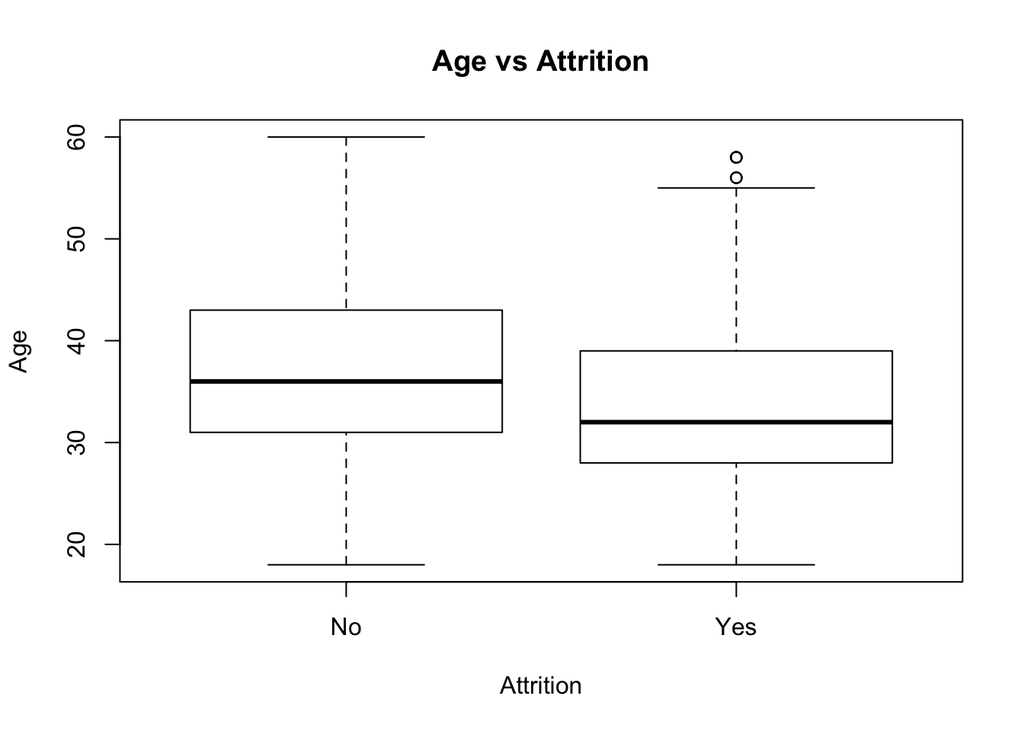

```r
boxplot(
  Age~Attrition,
  data=hrData,
  main="Age vs Attrition",
  xlab="Attrition",
  ylab="Age")
```

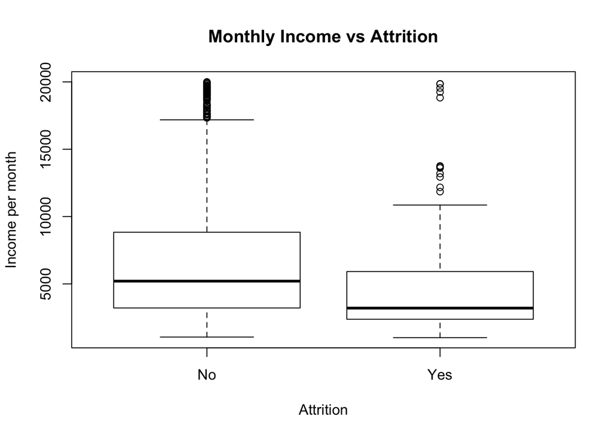

```r
boxplot(MonthlyIncome~Attrition,data=hrData, main="Monthly Income vs Attrition",
   xlab="Attrition", ylab="Income per month")
```

## Finding patterns in data

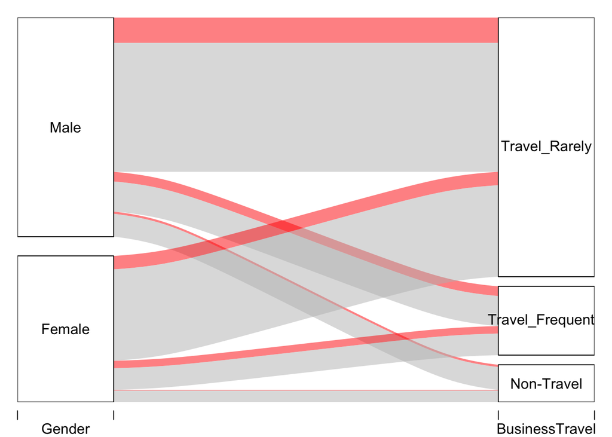

```r
p <- hrData %>%
  group_by(Gender, BusinessTravel, Attrition)%>%
  count()

alluvial(p[,1:2], freq=p$n, border=NA,
         #hide = p$n < quantile(p$n,.50),
         col=ifelse(p$Attrition == "Yes", "red", "gray"))
```

```r
female <- hrData %>% filter(Gender == "Female")
femaleFrequentTraveller <- hrData %>% filter(Gender == "Female", BusinessTravel == "Travel_Frequently")

table(female$Attrition)
```

```
##
##  No Yes
## 501  87
```

```r
table(femaleFrequentTraveller$Attrition)
```

```
##
##  No Yes
##  87  30
```

The frequent travelling female seem to be leaving the company at higher rate than the regular females.

### More Exploration

```r
#create new object with all the categorical variables removed
hrDataNum <- hrData %>% select(AttrBin, Age, DailyRate, DistanceFromHome, HourlyRate, MonthlyIncome, MonthlyRate, NumCompaniesWorked, OverTimeBin, PercentSalaryHike, TotalWorkingYears, TrainingTimesLastYear, YearsAtCompany, YearsInCurrentRole, YearsSinceLastPromotion, YearsWithCurrManager)

#view table
summary(hrDataNum) %>% kable() %>% kable_styling()
```

|  | AttrBin | Age | DailyRate | DistanceFromHome | HourlyRate | MonthlyIncome | MonthlyRate | NumCompaniesWorked | OverTimeBin | PercentSalaryHike | TotalWorkingYears | TrainingTimesLastYear | YearsAtCompany | YearsInCurrentRole | YearsSinceLastPromotion | YearsWithCurrManager |
| --- | --- | --- | --- | --- | --- | --- | --- | --- | --- | --- | --- | --- | --- | --- | --- | --- |
|  | Min. :0.0000 | Min. :18.00 | Min. : 102.0 | Min. : 1.000 | Min. : 30.00 | Min. : 1009 | Min. : 2094 | Min. :0.000 | Min. :0.000 | Min. :11.00 | Min. : 0.00 | Min. :0.000 | Min. : 0.000 | Min. : 0.000 | Min. : 0.000 | Min. : 0.000 |
|  | 1st Qu.:0.0000 | 1st Qu.:30.00 | 1st Qu.: 465.0 | 1st Qu.: 2.000 | 1st Qu.: 48.00 | 1st Qu.: 2911 | 1st Qu.: 8047 | 1st Qu.:1.000 | 1st Qu.:0.000 | 1st Qu.:12.00 | 1st Qu.: 6.00 | 1st Qu.:2.000 | 1st Qu.: 3.000 | 1st Qu.: 2.000 | 1st Qu.: 0.000 | 1st Qu.: 2.000 |
|  | Median :0.0000 | Median :36.00 | Median : 802.0 | Median : 7.000 | Median : 66.00 | Median : 4919 | Median :14236 | Median :2.000 | Median :0.000 | Median :14.00 | Median :10.00 | Median :3.000 | Median : 5.000 | Median : 3.000 | Median : 1.000 | Median : 3.000 |
|  | Mean :0.1612 | Mean :36.92 | Mean : 802.5 | Mean : 9.193 | Mean : 65.89 | Mean : 6503 | Mean :14313 | Mean :2.693 | Mean :0.283 | Mean :15.21 | Mean :11.28 | Mean :2.799 | Mean : 7.008 | Mean : 4.229 | Mean : 2.188 | Mean : 4.123 |
|  | 3rd Qu.:0.0000 | 3rd Qu.:43.00 | 3rd Qu.:1157.0 | 3rd Qu.:14.000 | 3rd Qu.: 83.75 | 3rd Qu.: 8379 | 3rd Qu.:20462 | 3rd Qu.:4.000 | 3rd Qu.:1.000 | 3rd Qu.:18.00 | 3rd Qu.:15.00 | 3rd Qu.:3.000 | 3rd Qu.: 9.000 | 3rd Qu.: 7.000 | 3rd Qu.: 3.000 | 3rd Qu.: 7.000 |
|  | Max. :1.0000 | Max. :60.00 | Max. :1499.0 | Max. :29.000 | Max. :100.00 | Max. :19999 | Max. :26999 | Max. :9.000 | Max. :1.000 | Max. :25.00 | Max. :40.00 | Max. :6.000 | Max. :40.000 | Max. :18.000 | Max. :15.000 | Max. :17.000 |

What’s the relationship between the different attributes? Use `corrplot()` to create correlation matrix.

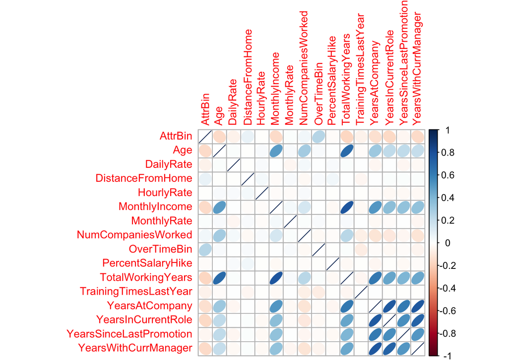

```r
#correlation plot
corrplot(cor(hrDataNum), type = "full", method = "ellipse", tl.cex = 0.9)
```

```r
# also create an object with only categorical variables
hrDataCat <- hrData%>%select(Attrition, BusinessTravel, Department, Education, EducationField, EnvironmentSatisfaction, Gender, JobRole, JobInvolvement, JobLevel, JobSatisfaction, MaritalStatus, OverTime, PerformanceRating, RelationshipSatisfaction, StockOptionLevel, WorkLifeBalance)
summary(hrDataCat) %>% kable() %>% kable_styling()
```

|  | Attrition | BusinessTravel | Department | Education | EducationField | EnvironmentSatisfaction | Gender | JobRole | JobInvolvement | JobLevel | JobSatisfaction | MaritalStatus | OverTime | PerformanceRating | RelationshipSatisfaction | StockOptionLevel | WorkLifeBalance |
| --- | --- | --- | --- | --- | --- | --- | --- | --- | --- | --- | --- | --- | --- | --- | --- | --- | --- |
|  | No :1233 | Non-Travel : 150 | Human Resources : 63 | 1:170 | Human Resources : 27 | 1:284 | Female:588 | Sales Executive :326 | 1: 83 | 1:543 | 1:289 | Divorced:327 | No :1054 | 3:1244 | 1:276 | 0:631 | 1: 80 |
|  | Yes: 237 | Travel_Frequently: 277 | Research & Development:961 | 2:282 | Life Sciences :606 | 2:287 | Male :882 | Research Scientist :292 | 2:375 | 2:534 | 2:280 | Married :673 | Yes: 416 | 4: 226 | 2:303 | 1:596 | 2:344 |
|  | NA | Travel_Rarely :1043 | Sales :446 | 3:572 | Marketing :159 | 3:453 | NA | Laboratory Technician :259 | 3:868 | 3:218 | 3:442 | Single :470 | NA | NA | 3:459 | 2:158 | 3:893 |
|  | NA | NA | NA | 4:398 | Medical :464 | 4:446 | NA | Manufacturing Director :145 | 4:144 | 4:106 | 4:459 | NA | NA | NA | 4:432 | 3: 85 | 4:153 |
|  | NA | NA | NA | 5: 48 | Other : 82 | NA | NA | Healthcare Representative:131 | NA | 5: 69 | NA | NA | NA | NA | NA | NA | NA |
|  | NA | NA | NA | NA | Technical Degree:132 | NA | NA | Manager :102 | NA | NA | NA | NA | NA | NA | NA | NA | NA |
|  | NA | NA | NA | NA | NA | NA | NA | (Other) :215 | NA | NA | NA | NA | NA | NA | NA | NA | NA |

# Build Model

1. Create a base model: with only numerical variables
2. Evaluate the model
3. Fix issues
4. Optimization

In all we have 34 features consisting of both the categorical as well as the numerical features. The target variable is the ‘Attrition’ of the employee which can be either a Yes or a No. This is what we have to predict.

Hence this is a Binary Classification problem.

```r
# Build train & test
set.seed(9876)
train <- sample(1:nrow(hrDataNum), nrow(hrDataNum)*.7)
test <- -train

trainData <- hrDataNum[train,]
testData <- hrDataNum[test,]
```

```r
#start with a full model
model1 <- glm(AttrBin~., data=trainData, family = binomial(link="logit"))

summary(model1)
```

```
##
## Call:
## glm(formula = AttrBin ~ ., family = binomial(link = "logit"),
##     data = trainData)
##
## Deviance Residuals:
##     Min       1Q   Median       3Q      Max
## -1.8111  -0.5865  -0.3993  -0.2146   3.1871
##
## Coefficients:
##                           Estimate Std. Error z value Pr(>|z|)
## (Intercept)              5.505e-01  7.288e-01   0.755 0.450049
## Age                     -5.161e-02  1.502e-02  -3.436 0.000591 ***
## DailyRate               -3.078e-04  2.302e-04  -1.337 0.181266
## DistanceFromHome         3.885e-02  1.145e-02   3.393 0.000692 ***
## HourlyRate              -3.031e-03  4.588e-03  -0.661 0.508820
## MonthlyIncome           -8.277e-05  3.791e-05  -2.183 0.029009 *
## MonthlyRate             -1.502e-05  1.325e-05  -1.133 0.257074
## NumCompaniesWorked       1.683e-01  3.923e-02   4.291 1.78e-05 ***
## OverTimeBin              1.621e+00  1.914e-01   8.470  < 2e-16 ***
## PercentSalaryHike       -1.433e-03  2.544e-02  -0.056 0.955081
## TotalWorkingYears       -1.862e-02  2.952e-02  -0.631 0.528176
## TrainingTimesLastYear   -9.162e-02  7.468e-02  -1.227 0.219885
## YearsAtCompany           5.982e-02  3.901e-02   1.533 0.125188
## YearsInCurrentRole      -9.974e-02  4.669e-02  -2.136 0.032669 *
## YearsSinceLastPromotion  8.612e-02  4.338e-02   1.985 0.047101 *
## YearsWithCurrManager    -1.138e-01  4.686e-02  -2.428 0.015187 *
## ---
## Signif. codes:  0 '***' 0.001 '**' 0.01 '*' 0.05 '.' 0.1 ' ' 1
##
## (Dispersion parameter for binomial family taken to be 1)
##
##     Null deviance: 932.07  on 1028  degrees of freedom
## Residual deviance: 763.92  on 1013  degrees of freedom
## AIC: 795.92
##
## Number of Fisher Scoring iterations: 5
```

The overtime indicator, age, distance from home, number of companies worked are the most significant indicators in this model.

```r
#looking for multi collinearity
car::vif(model1)
```

```
##                     Age               DailyRate        DistanceFromHome
##                1.929606                1.017389                1.046360
##              HourlyRate           MonthlyIncome             MonthlyRate
##                1.011981                2.240168                1.028753
##      NumCompaniesWorked             OverTimeBin       PercentSalaryHike
##                1.330092                1.076333                1.025896
##       TotalWorkingYears   TrainingTimesLastYear          YearsAtCompany
##                4.436333                1.015994                5.070462
##      YearsInCurrentRole YearsSinceLastPromotion    YearsWithCurrManager
##                2.539821                2.095687                2.510001
```

There is problems with multi-collinearity with the total working years, monthly income, years at company, years in current role which could be removed while building the next model.

```r
# Accesing the predective ability of the logistic regression model
predictTest1 <- predict(model1, newdata = testData, type='response')

#setting up cutoff at 0.5
predictTest1 <- if_else((predictTest1 >= 0.5), 1, 0)

# Create confusion matrix
caret::confusionMatrix(factor(predictTest1), factor(testData$AttrBin))
```

```
## Confusion Matrix and Statistics
##
##           Reference
## Prediction   0   1
##          0 364  51
##          1  13  13
##
##                Accuracy : 0.8549
##                  95% CI : (0.8185, 0.8864)
##     No Information Rate : 0.8549
##     P-Value [Acc > NIR] : 0.5333
##
##                   Kappa : 0.2238
##  Mcnemar's Test P-Value : 3.746e-06
##
##             Sensitivity : 0.9655
##             Specificity : 0.2031
##          Pos Pred Value : 0.8771
##          Neg Pred Value : 0.5000
##              Prevalence : 0.8549
##          Detection Rate : 0.8254
##    Detection Prevalence : 0.9410
##       Balanced Accuracy : 0.5843
##
##        'Positive' Class : 0
##
```

Gives an accuracy of 85% and a sensitivity of 96%, but the multi collinearity issue is significant. We need to build a better model.

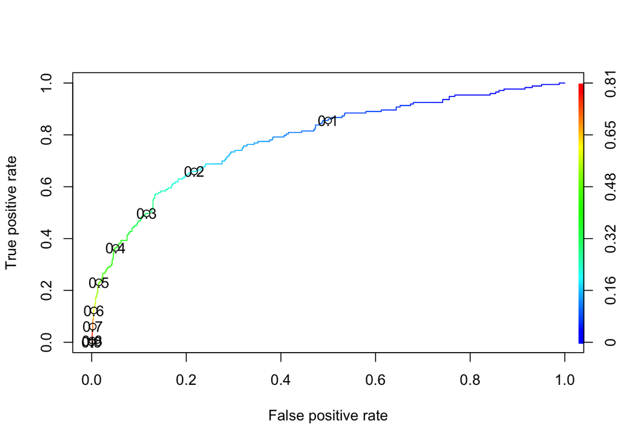

```r
# Plotting the ROC curve
predictTrain1 <- predict(model1, trainData, type = "response")
ROCRPred <- prediction(predictTrain1, trainData$AttrBin)
ROCRPerf <- performance(ROCRPred,"tpr","fpr")
plot(ROCRPerf,colorize = TRUE, print.cutoffs.at = seq(0.1, by = 0.1))
```